# Introduction to Machine Learning - Exercises, Part 1 and 2

We need the following packages.

```r
library(tidyverse)
library(plotROC)
library(pROC)
library(shiny)
library(caret)
library(class)
library(KernSmooth)  #package for locpoly
```

## Exercise 1 (classification rules and misclassification error estimation)

We consider the following data set

```r
n <- 1000
seuil <- 0.25
set.seed(1234)
X1 <- runif(n)
set.seed(5678)
X2 <- runif(n)
set.seed(9012)
R1 <- X1<=0.25
R2 <- (X1>0.25 & X2>=0.75)
R3 <- (X1>0.25 & X2<0.75)
Y <- rep(0,n)
Y[R1] <- rbinom(sum(R1),1,0.25)
Y[R2] <- rbinom(sum(R2),1,0.25)
Y[R3] <- rbinom(sum(R3),1,0.75)
my_data <- data.frame(X1,X2,Y)
my_data$Y <- as.factor(my_data$Y)
```

The problem is to explain $Y$ by $X_1$ and $X_2$.

1. What is the distribution of $X$? Same question for $Y|X=x$ with $x\in[0,1]^2$.

We can observe that $X$ has a uniform distribution on the square $[0,1]^2$. $Y|X=x$ has a Bernoulli distribution with parameter

- 0.25 if $x_1\leq 0.25$ or $x_1>0.25$ end $x_2\geq 0.75$.
- 0.75 otherwise.
2. Calculate the Bayes rule and the Bayes error.

We deduce that the Bayes rule is given by

$$g^\star(x)=\left\{
\begin{array}{ll}
0 & \text{if }x_1\leq 0.25 \text{ or if }(x_1>0.25\text{ and }x_2\geq 0.75)\\
1 & \text{otherwise.}
\end{array}\right.$$

Bayes error equals $L^\star=0.25$.

3. Draw the scatterplot $X_2\times X_1$ and color the points according to the label $Y$.

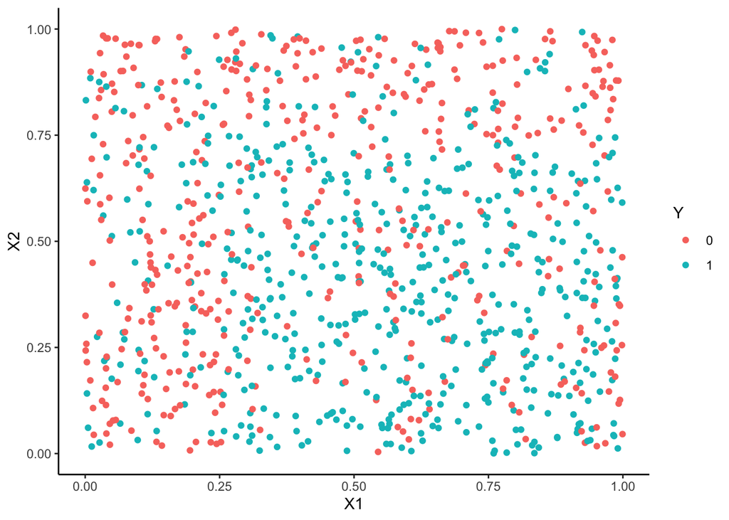

```r
ggplot(my_data)+aes(x=X1,y=X2,color=Y)+geom_point()+theme_classic()
```

4. We consider 3 classification rules:
   $$g_1(x)=1_{x_1>x_2}(x),\quad g_2(x)=1_{x_2<0.5}(x),\quad g_3(x)=1_{x_1>0.25}(x).$$
   Calculate $g_\ell(X_i)$ for each observation in **my_data** (you can use **as.numeric**). Put all predictions in the same **dataframe**.

```r
g1 <- as.numeric(my_data$X1>my_data$X2)
g2 <- as.numeric(my_data$X2<0.5)
g3 <- as.numeric(my_data$X1>0.25)
prev <- data.frame(g1=g1,g2=g2,g3=g3,Y=my_data$Y)
```

5. Estimate error probabilities $P(g_j(X)\neq Y)$ for each classification rule $g_j$.

We compute
$$\frac{1}{n}\sum_{i=1}^n1_{g_j(X_i)\neq Y_i}.$$

```r
prev %>% summarise_at(1:3,~mean(Y!=.))
```

| g1 | g2 | g3 |
| --- | --- | --- |
| 0.36 | 0.398 | 0.365 |

6. We consider the one-nearest neigbor rule defined by
   $$\widehat g_1(x)=\left\{
   \begin{array}{ll}
   1 & \text{if }Y(x)=1 \\
   0 & \text{otherwise,}
   \end{array}\right.$$

where $Y(x)$ stands for the label of the nearest neighbor of $x$ among $\{X_1,\dots,X_n\}$. Split the data into

- a train dataset of size 750
- a test dataset of size 250.

```r
set.seed(1234)
perm <- sample(nrow(my_data))
train <- my_data %>% slice(perm[1:750])
test <- my_data %>% slice(perm[751:1000])
```

7. Estimate the error probability of the 1-nearest neigbor rule $\widehat g_1$. You can use the **knn** function from the **class** package.

We denote by $\widehat g_1$ the 1NN rule defined on the training set. We estimate its error probability by :
$$\frac{1}{n_{test}}\sum_{i\in test}1_{\widehat g_1(X_i)\neq Y_i}.$$

```r
pred_1NN <- knn(train[,1:2],test[,1:2],train$Y,k=1)
df <- data.frame(obs=test$Y,pred=pred_1NN)
df %>% summarize(Err=mean((obs!=pred)))
```

| Err |
| --- |
| 0.4 |

## Exercise 2 (ROC curves)

We consider three scores $S_1,S_2$ and $S_3$ for 100 individuals. We have also at hand the labels of each individuals in the vector $Y$. Score and labels are in the following data frame:

```r
set.seed(1234)
S1 <- runif(100)
S2 <- runif(100)
S3 <- S1
S3[sample(100,25)] <- runif(25)
Y <- rep(0,n)
Y[S1>0.5] <- 1
df <- data.frame(S1,S2,S3,Y=as.factor(Y))
```

1. Represent score values with a different color for each group.

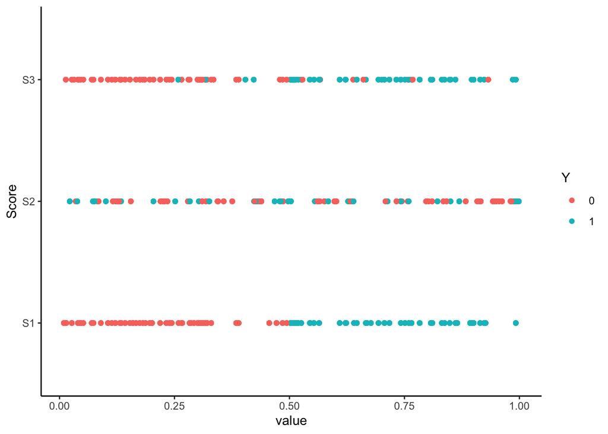

```r
df1 <- df %>% gather(key="Score",value="value",-Y)
ggplot(df1)+aes(x=value,y=Score,color=Y)+geom_point()+theme_classic()
```

2. Draw the roc curve of $S_1$ with the **roc** function of the **pROC** package.

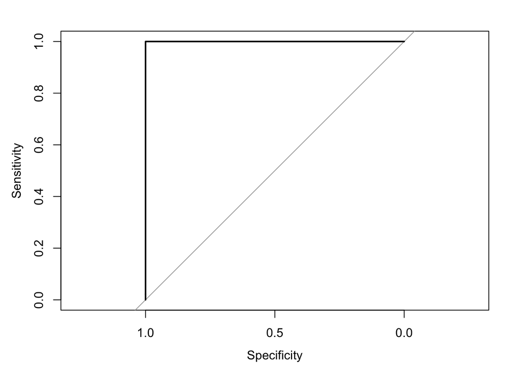

```r
plot(roc(df$Y,df$S1))
```

3. Add roc curves of $S_2$ and $S_3$.

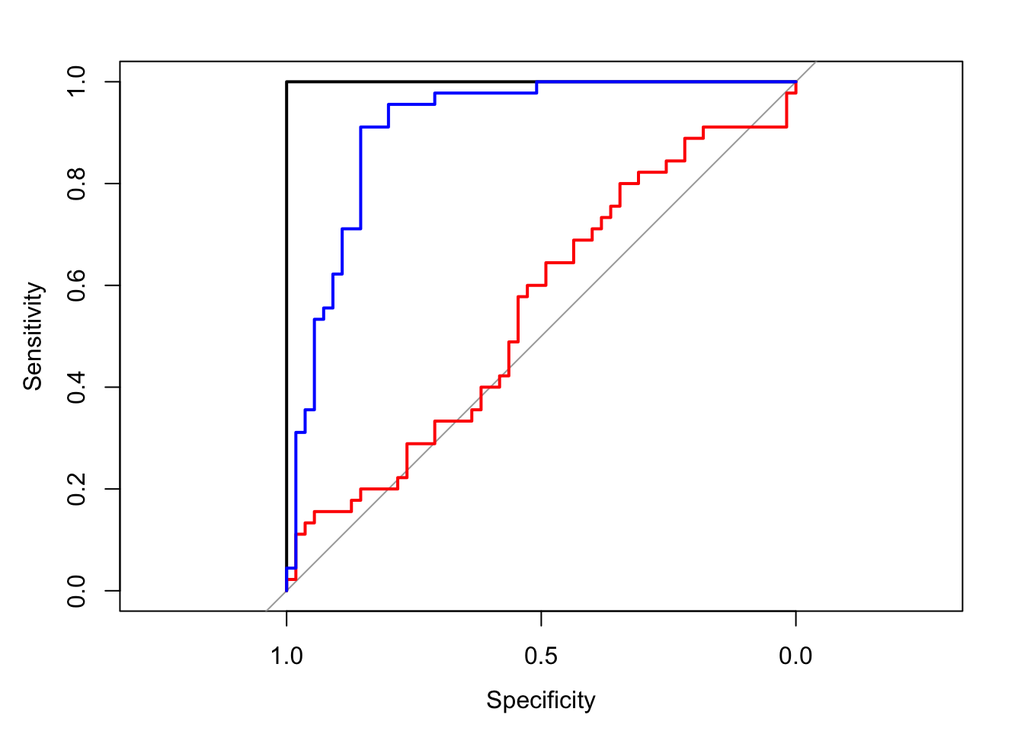

```r
plot(roc(df$Y,df$S1))
plot(roc(df$Y,df$S2),add=TRUE,col="red")
plot(roc(df$Y,df$S3),add=TRUE,col="blue")
```

4. Calculate AUC of the three scores.

```r
auc(df$Y,df$S1)
```

```
## Area under the curve: 1
```

```r
auc(df$Y,df$S2)
```

```
## Area under the curve: 0.5519
```

```r
auc(df$Y,df$S3)
```

```
## Area under the curve: 0.9111
```

5. Draw the three roc curves with the **geom_roc** function of the **plotROC** package (use **gather** to simplify the code).

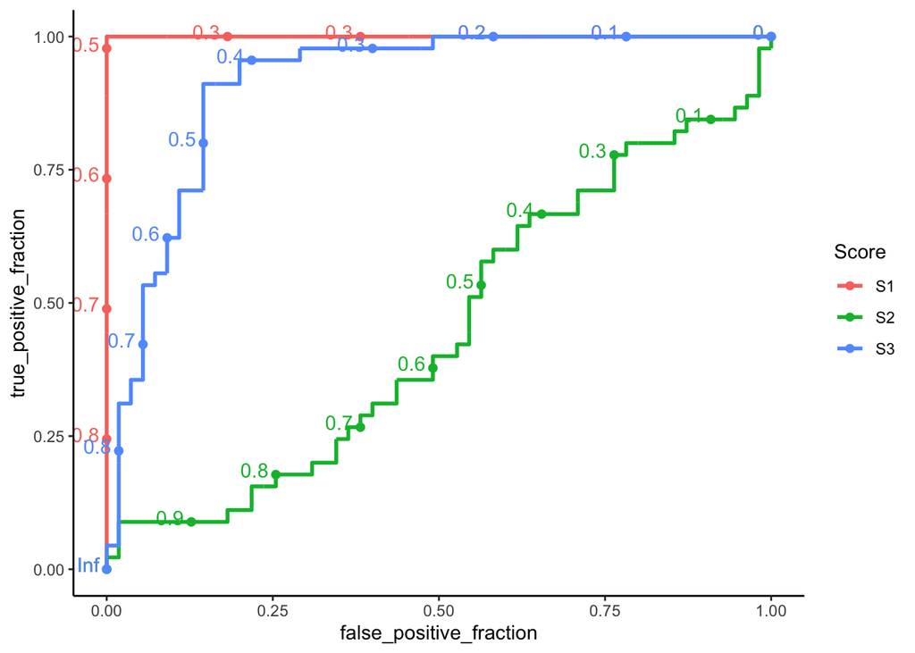

```r
df1 <- df %>% gather(key="Score",value="value",-Y)
df1$Y <- df1$Y %>% as.numeric()-1
ggplot(df1)+aes(d=Y,m=value,color=Score)+geom_roc()+theme_classic()
```

6. Compute AUC of the 3 scores with **summarize** verb.

```r
df1 %>% group_by(Score) %>% summarize(AUC=auc(Y,value)) %>% arrange(desc(AUC))
```

| Score | AUC |
| --- | --- |
| S1 | 1.0000000 |
| S3 | 0.9111111 |
| S2 | 0.5519192 |